# Lab10 - Titanic Data

tony sulfaro

3/14/2019

### Get some dependencies

```r
library(tidyverse)
#install.packages("gapminder")
library("gapminder")
?gapminder
#install.packages("magrittr") # only needed the first time you use it
#install.packages("dplyr")    # alternative installation of the %>%
library(magrittr) # need to run every time you start R and want to use %>%
library(dplyr)    # alternative, this also loads %>%
```

## Question 01

### Jobs dataset

Let us read in the jobs dataset and see what it is all about

```r
jobs = read.csv("jobs.csv", header=TRUE)
```

Per the documentation the jobs.csv dataset includes “reported occupations in the United States Labor Force from 1850-2000. The data is originally from the United States Census Bureau and was provided by the University of Minnesota Population Center (ipums.org)”.

The dataset is arranged into 5584 rows and 6 columns.

This particular data was arranged in 1950 into the respective categories (columns):

- year: census year
- sex: M (male) or F (female)
- occupation: the occupation type
- people: people with that occupation in that year
- n.by.year: total number of people for that year
- proportion: proportion of males or females in a given year who reported a given occupation

### Here is what a row looks like of this dataset

```r
head(jobs, 1)
```

```
##   year sex           occupation people n.by.year  proportion
## 1 2000   M Accountant / Auditor 866460 168122353 0.005153747
```

## Question 02

### Mean and standard deviation of jobs dataset between 1910 and 2000 for occupation = Clerical Worker

Filter the dataset

```r
jobs %>% filter(occupation=="Clerical Worker") %>% filter(year >= 1910 & year <= 2000) %>% summarize(Mean = mean(proportion), Standard_Deviation = sd(proportion))
```

```
##         Mean Standard_Deviation
## 1 0.02625589         0.01486836
```

We can see here the average proportion of clerical worker between the years 1910 and 2000 as well as the standard deviation.

## Question 03

There are 255 different occupations in the dataset.

## Question 04

Occupation with the maximum proportion.

```r
head(jobs %>% group_by(occupation) %>% arrange(desc(proportion)), 1)
```

```
## # A tibble: 1 x 6
## # Groups:   occupation [1]
##    year sex   occupation  people n.by.year proportion
##   <int> <fct> <fct>        <int>     <int>      <dbl>
## 1  1850 M     Farmer     2415878   5406202      0.447
```

It would appear that the occupation: Farmer has the highest proportion of men for this sample.

# Titanic Dataset

## Question 05

First things first lets actually get the data.

```r
titanic = read.csv("Titanic_Passengers.csv")
```

Distribution of ages on the Titanic.

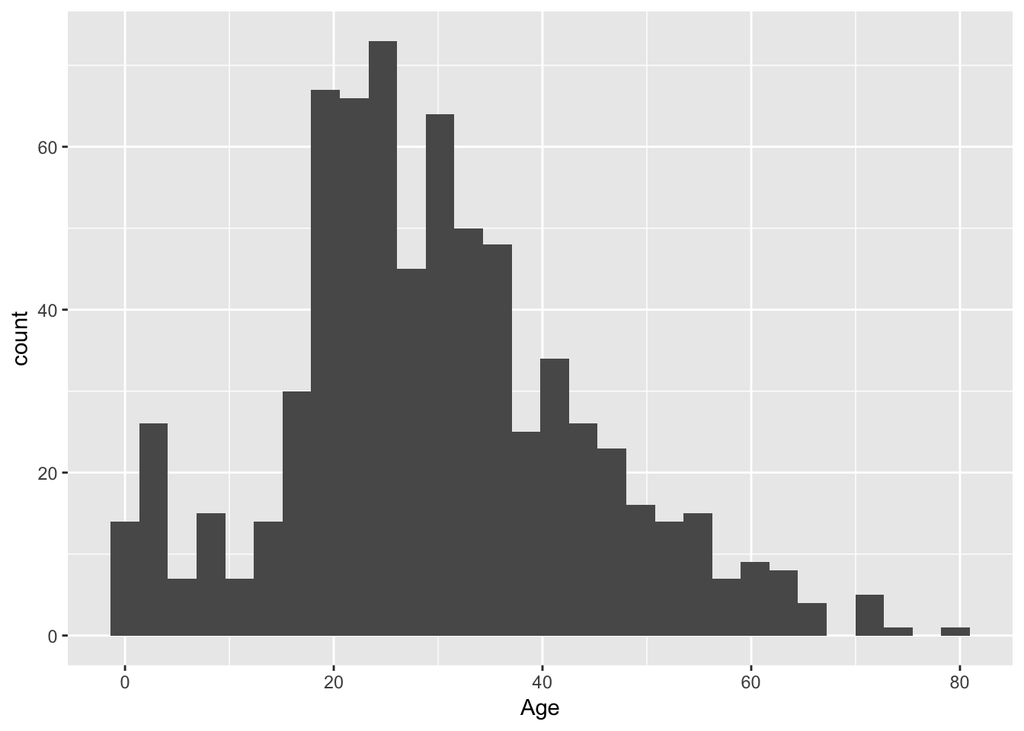

```r
titanic %>% ggplot(aes(Age)) + geom_histogram()
```

## Question 06

There are too many bins in that. Time to get it under control.

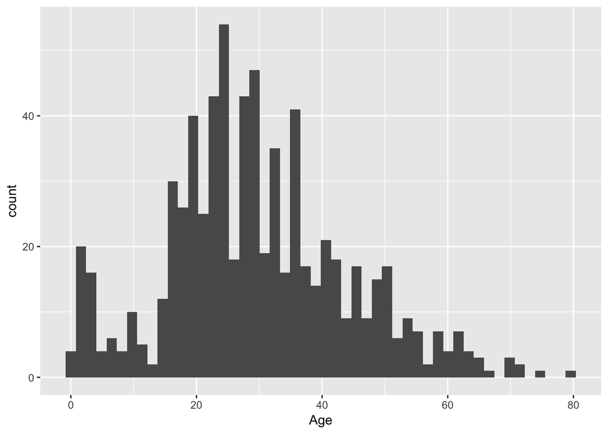

```r
titanic %>% ggplot(aes(Age)) + geom_histogram(bins = 50)
```

## Question 07

The graph is getting closer. This time let’s modify the width of bins.

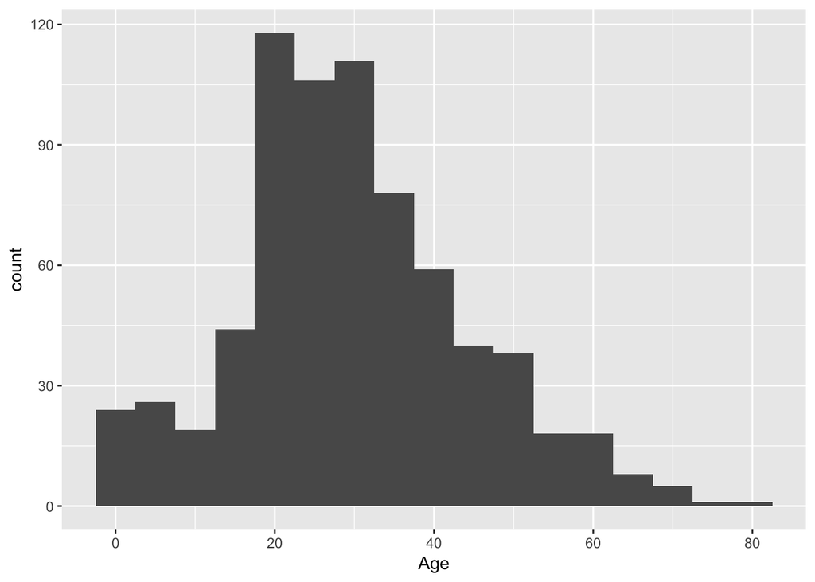

```r
titanic %>% ggplot(aes(Age)) + geom_histogram(bins = 50, binwidth = 5)
```

the binwidth parameter in geom_histogram() is

“The width of the bins. Can be specified as a numeric value, or a function that calculates width from x. The default is to use bins bins that cover the range of the data. You should always override this value, exploring multiple widths to find the best to illustrate the stories in your data.”

per the ggplot2 documentation.

## Question 08

The graphs in questions 5,6,7 differ in that the first graph (5) defaults to a bin count of 30. The next graph (6) ovverides that by setting bins = 50 which makes more columns for the ages within the range of the data. Graph (7) is different from all those in that it manually sets the number of bins = 50 and sets the binwidth = 5, making the bars wider.

## Question 09

The average age of females on the titanic: 27.9157088 years.

The average age of males on the titanic: 30.7266446 years.

Disclaimer: Null ages were removed to calculate this information from the sample.

## Question 10

Mean and standard deviation of the fares people paid for tickets in each passenger class on the Titanic, and how many passengers bought tickets in each fare class.

```r
titanic %>% group_by(Class =Pclass) %>% summarise(Mean = mean(Fare), Standard_Deviation = sd(Fare), Count = n())
```

```
## # A tibble: 3 x 4
##   Class  Mean Standard_Deviation Count
##   <int> <dbl>              <dbl> <int>
## 1     1  84.2               78.4   216
## 2     2  20.7               13.4   184
## 3     3  13.7               11.8   491
```

We can see that as the class level “increases” (becomes more luxurious) it does on average increase on price.

## Question 11

```r
# get highest mean
highest_mean = head(titanic %>% group_by(Class =Pclass) %>% summarise(Mean = mean(Fare), Standard_Deviation = sd(Fare), Count = n()) %>% arrange(desc(Mean)),1)[,2]

# get highest mean class
highest_mean_class = head(titanic %>% group_by(Class =Pclass) %>% summarise(Mean = mean(Fare), Standard_Deviation = sd(Fare), Count = n()) %>% arrange(desc(Mean)),1)[,1]

# get highest variability class
highest_var_class = head(titanic %>% group_by(Class =Pclass) %>% summarise(Mean = mean(Fare), Standard_Deviation = sd(Fare), Count = n()) %>% arrange(desc(Standard_Deviation)),1)[,1]

# get highest_variability
highest_variability = head(titanic %>% group_by(Class =Pclass) %>% summarise(Mean = mean(Fare), Standard_Deviation = sd(Fare), Count = n()) %>% arrange(desc(Standard_Deviation)),1)[,3]

# highest passenger count

highest_pass_class = head(titanic %>% group_by(Class =Pclass) %>% summarise(Mean = mean(Fare), Standard_Deviation = sd(Fare), Count = n()) %>% arrange(desc(Count)),1)[,1]

highest_pass_count = head(titanic %>% group_by(Class =Pclass) %>% summarise(Mean = mean(Fare), Standard_Deviation = sd(Fare), Count = n()) %>% arrange(desc(Count)),1)[,4]
```

### Calculation table

```r
titanic %>% group_by(Class =Pclass) %>% summarise(Mean = mean(Fare), Standard_Deviation = sd(Fare), Count = n()) %>% arrange(desc(Count))
```

```
## # A tibble: 3 x 4
##   Class  Mean Standard_Deviation Count
##   <int> <dbl>              <dbl> <int>
## 1     3  13.7               11.8   491
## 2     1  84.2               78.4   216
## 3     2  20.7               13.4   184
```

Which fare class was the most expensive?

- The most expensive class was class = 1 or the upper class. Look at highest mean = 84.1546875 and in the same row it is class = 1.

Which had the highest variability?

- The class with the highest variability was class = 1. You can match up the highest standard deviation = 78.3803726 with class = 1.

Which class had the most passengers?

- Class = 3 had the most passengers at count = 491.

## Question 12

Show countries in Europe GDP per cap distribution.

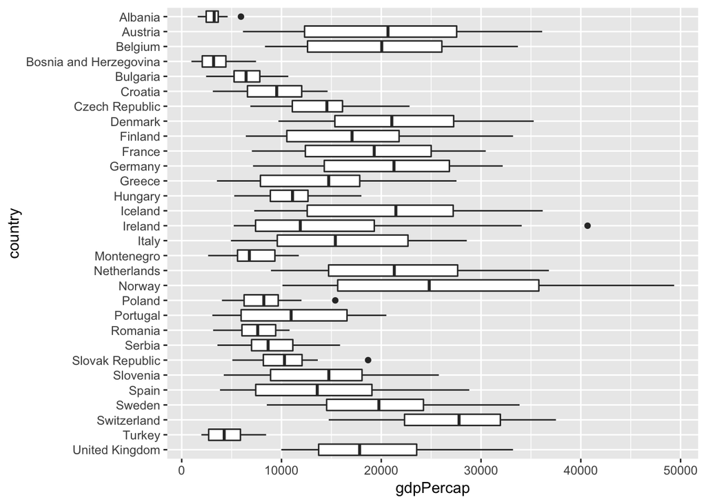

```r
gapminder %>%
  arrange(desc(country)) %>%
  mutate(country = factor(country, levels = unique(country))) %>%
  filter(continent=="Europe") %>%
  ggplot(aes(x=country, y=gdpPercap)) +
  geom_boxplot() + coord_flip()
```

## Question 13

Already arranged in alphabetical order.

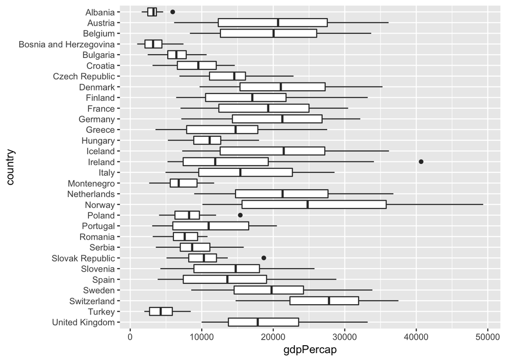

```r
gapminder %>%
  arrange(desc(country)) %>%
  mutate(country = factor(country, levels = unique(country))) %>%
  filter(continent=="Europe") %>%
  ggplot(aes(x=country, y=gdpPercap)) +
  geom_boxplot() + coord_flip()
```

## Question 14

Filter plot to only countries: Hungary, Iceland, Greece, and Switzerland.

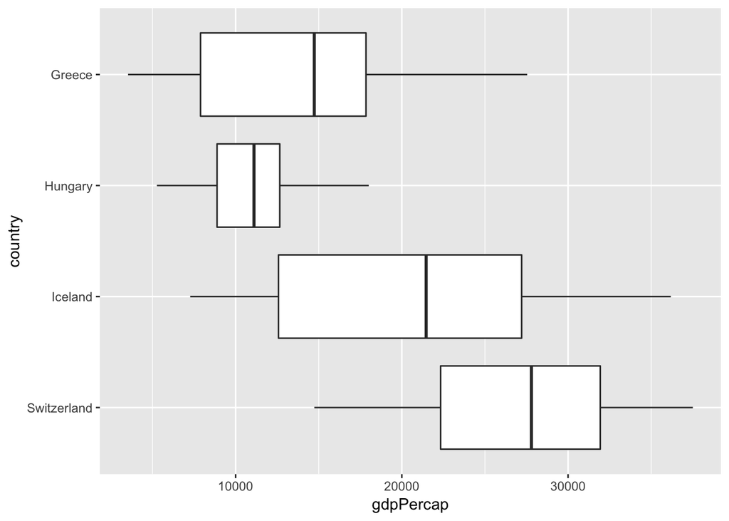

```r
gapminder %>%
  arrange(desc(country)) %>%
  mutate(country = factor(country, levels = unique(country))) %>%
  filter(continent=="Europe") %>%
  filter(country == "Hungary" | country == "Iceland" | country == "Greece" | country == "Switzerland") %>%
  ggplot(aes(x=country, y=gdpPercap)) +
  geom_boxplot() + coord_flip()
```

## Question 15

The line in the middle of the boxes represent the median value. In this case, it is the median GDP per capita in US dollars.

## Question 16

### Titanic passenger class with the highest survival percentage

Let’s start out with a simple stacked bar chart to visually quantify the data.

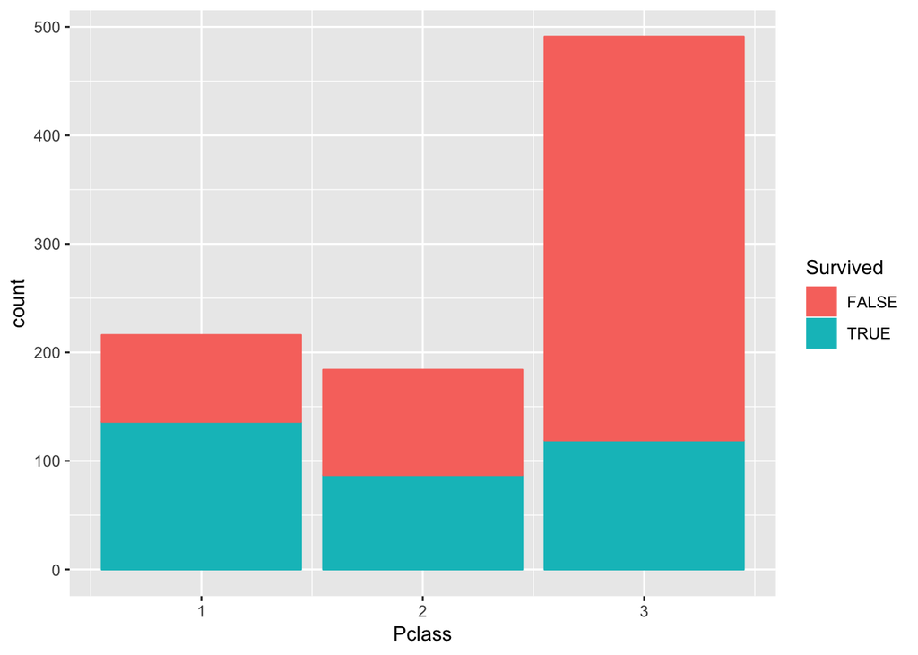

```r
titanic %>% mutate(Survived = (Survived==1)) %>%
  ggplot(aes(x=Pclass, group=Survived, color=Survived)) + geom_bar(aes(fill = Survived))
```

It looks like people on the lowest deck (3rd) had a higher percentage of deaths than all other classes. Lets calculate the actual percentages.

```r
titanic %>% group_by(Class =Pclass) %>% summarise(Passenger_Count = n(), Survived_Count = nrow(subset(titanic,Survived==1 & Pclass==Class)), Perished_Count = nrow(subset(titanic,Survived==0 & Pclass==Class)), Survival_Percentage = 100*(Survived_Count/Passenger_Count))
```

```
## # A tibble: 3 x 5
##   Class Passenger_Count Survived_Count Perished_Count Survival_Percentage
##   <int>           <int>          <int>          <int>               <dbl>
## 1     1             216            136             80                63.0
## 2     2             184             87             97                47.3
## 3     3             491            119            372                24.2
```

Yes, the lower deck (class 3) has the lowest percentage of people that survived.

## Question 17

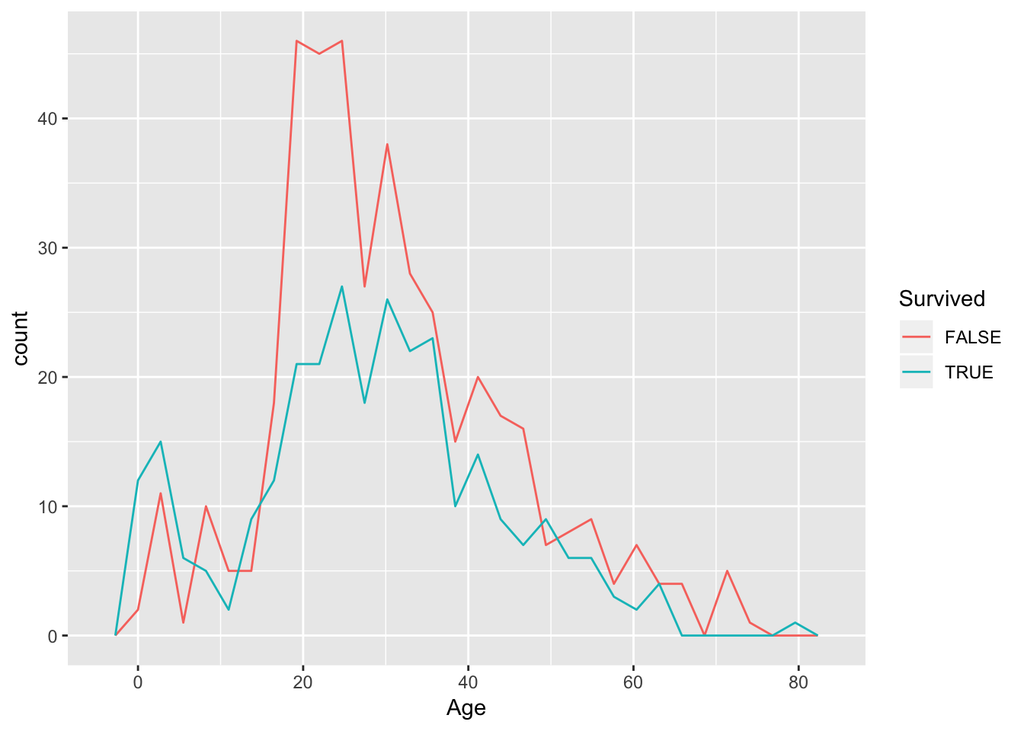

```r
titanic %>% mutate(Survived = (Survived==1)) %>%
  ggplot(aes(x=Age, group=Survived, color=Survived)) + geom_freqpoly()
```

## Question 18

For both the graphs it shows that those not in the lower decks were more likely to survive. The proportion of people that died on the lowest deck it is quite large and as the deck levels increase (3 to 1) the percentage of people the survived also increases. Small children from the ages of approximately 0-5 were also likely to survive compared to people older than them.